# MA4M4 Coding Examples PART 2

Welcome to the second coding example.

The aim of this notebook is to keep you practising and exploring the functionality of networkx (or equivalent) through applications of concepts and examples from the lecture notes.

After this coding example, you should be able to:

1. Confidently import and build a network from raw network data.
2. Generate a Watts Stogatz graph.
3. Call built in random network models such as Erdos Renyi and Configuration model.

Together with the first Jupyter notebook, these will constitute a good basis for the upcoming lab sessions.

```python
# If packages are not available, try running pip install in the command line [conda prompt in Windows system].
# It can sometimes also be useful to check any constraints on Python version compatibility
import pandas as pd
import networkx as nx
import numpy as np
import matplotlib.pyplot as plt
```

Use the networkx.random_graphs.watts_strogatz_graph to generate some WS graph with parameters you choose. Try to visualize the graph using nx.draw in a suitable layout.

Try out the example in L3 slides. Changing the p from 0-1 inclusive and check how this influence the averge shortest path between vertices and average clustering coefficient. Plot the values of these two quantities normalized the first value.

```
p value is  0.0
```

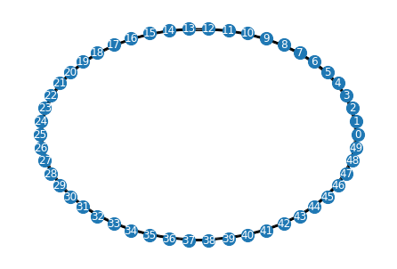

```
p value is  0.05
```

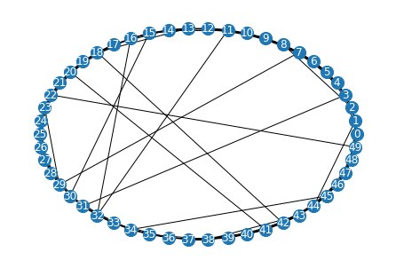

```
p value is  0.1
```

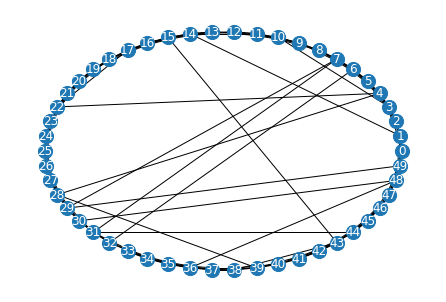

```
p value is  0.15000000000000002
```

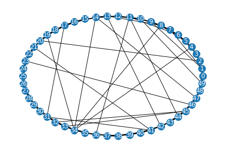

```
p value is  0.2
```

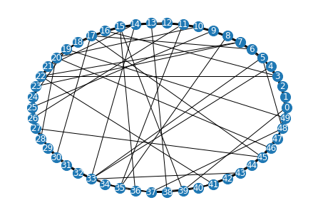

```
p value is  0.25
```

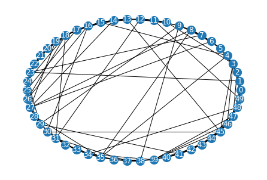

```
p value is  0.30000000000000004
```

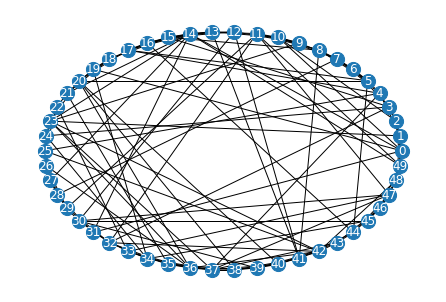

```
p value is  0.35000000000000003
```

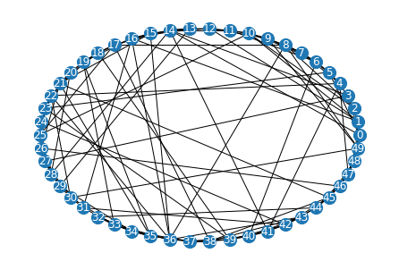

```
p value is  0.4
```

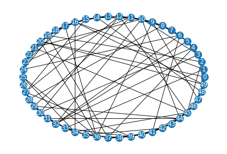

```
p value is  0.45
```

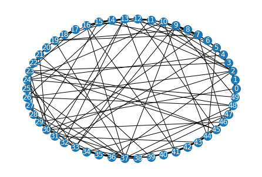

```
p value is  0.5
```

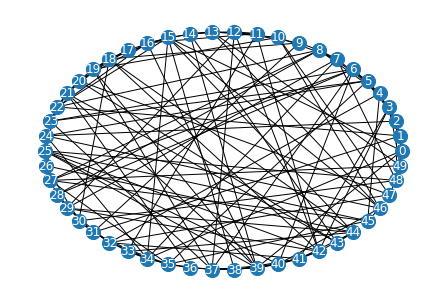

```
p value is  0.55
```

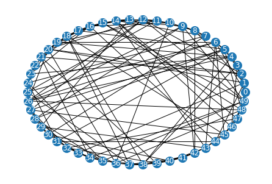

```
p value is  0.6000000000000001
```

[8 more figures not shown]

```python
p_list = np.arange(0,1,0.05)
N = 50;
k = 6;
average_sp = np.zeros((len(p_list),1))# average shortest path list
average_cc = np.zeros((len(p_list),1))# average clustering coef list
for idx,p in enumerate(p_list):

    # Generate Watts strogatz graph using the networkx random graph generator
    G_temp = nx.random_graphs.watts_strogatz_graph(N,k,p)
    # visualize a network using circular layout
    print('p value is ',p)
    nx.draw(G_temp,pos=nx.circular_layout(G_temp),with_labels=True,node_size=200,font_color='white')
    plt.show()
    average_sp[idx] = nx.average_shortest_path_length(G_temp)
    average_cc[idx] = nx.average_clustering(G_temp)
```

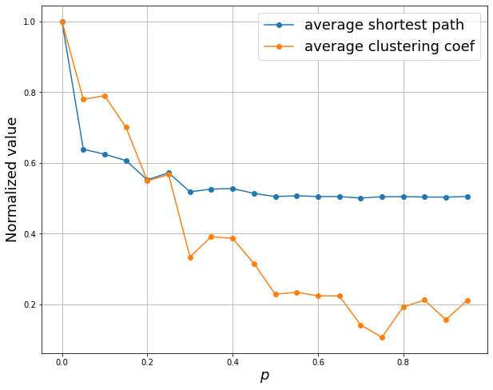

```python
plt.figure(figsize=(10,8))
# Normalize starting point to be 1
plt.plot(p_list,average_sp/(average_sp[0]),'o-',label = 'average shortest path')
plt.plot(p_list,average_cc/(average_cc[0]),'o-',label = 'average clustering coef')
plt.legend(fontsize=18)
plt.grid()
plt.ylabel('Normalized value',fontsize=18)
plt.xlabel(r'$p$',fontsize=18)
```

## Random Graph Model

In the following section, we will focus on random graph model. We will look up ERRG and Configuration model.

1. In networkx, there are many built in random graph generators. Here, we mainly use [ER](https://networkx.org/documentation/stable/reference/generated/networkx.generators.random_graphs.erdos_renyi_graph.html#networkx.generators.random_graphs.erdos_renyi_graph) and [configuration model](https://networkx.org/documentation/stable/reference/generated/networkx.generators.degree_seq.configuration_model.html).
2. Play with generators using different parameters and visualize them.

```python
N = 100
p = 0.01
G_ER = nx.gnp_random_graph(N,p)
```

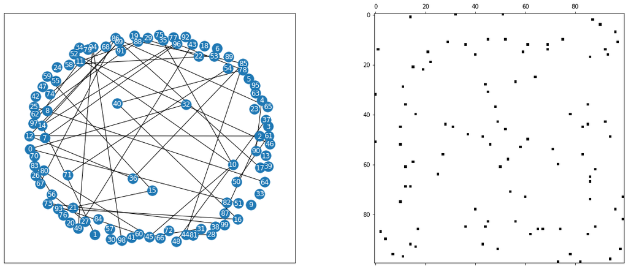

```python
plt.figure(figsize=(20,8))
plt.subplot(1,2,1)
nx.draw(G_ER,
        pos=nx.spring_layout(G_ER,k=1.5,seed = 2022),
        with_labels=True, font_color='w')
plt.axis("on")
plt.subplot(1,2,2)
plt.spy(nx.to_numpy_matrix(G_ER))
```

```python
degree= [d for u,d in G_ER.degree()]
print("Average degree is", np.sum(degree)/N)
print("(N-1)*p is", (N-1)*p)
```

```
Average degree is 0.98
(N-1)*p is 0.99
```

Let's compute (mean) average degree of large ensembles of graphs.

```python
SIM_NUM=1000;
mean_degree = np.zeros((SIM_NUM,1))
for i in range(0,SIM_NUM):
    G = nx.gnp_random_graph(N,p)
    degree = [d for u,d in G.degree()]
    mean_degree[i] = np.sum(degree)/N
print('average degree over all simulations',np.mean(mean_degree))
```

```
average degree over all simulations 0.9916800000000001
```

### Generate a relatively sparse network i.e p small, identify and visualize first and second connected components.

```python
print(nx.number_connected_components(G_ER))
```

```
51
```

```python
gcc = G_ER.subgraph(sorted(nx.connected_components(G_ER), key=len, reverse=True)[0]);
second_cc =G_ER.subgraph(sorted(nx.connected_components(G_ER), key=len, reverse=True)[1])
```

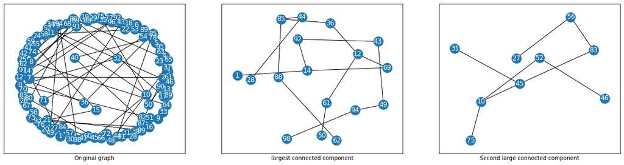

```python
plt.figure(figsize=(20,5))
plt.subplot(1,3,1)
nx.draw(G_ER,
        pos=nx.spring_layout(G_ER,k=1.5,seed = 2022),
        with_labels=True, font_color='w')
plt.axis("on");
plt.xlabel('Original graph');
plt.subplot(1,3,2)
nx.draw(gcc,
        pos = nx.spring_layout(gcc,k=1.5,seed = 2022),
        with_labels=True, font_color='w')
plt.axis("on");
plt.xlabel('largest connected component');
plt.subplot(1,3,3)
nx.draw(second_cc,
        pos = nx.spring_layout(second_cc,k=1.5,seed =2022),
        with_labels=True, font_color='w')
plt.axis("on");
plt.xlabel('Second large connected component');
```

### Vary c (average degree parameter) and see the emergence of giant component.

```python
c_list = np.linspace(0,5,100)
N=1000;
NUM_SIM = 5;
size_giant_component = np.zeros((len(c_list),NUM_SIM))
for idx, c in enumerate(c_list):
    for sim in range(NUM_SIM):
        # using c = (N-1)p
        G_temp = nx.gnp_random_graph(N,c/(N-1))
        largest_cc = max(nx.connected_components(G_temp), key=len)
        size_giant_component[idx,sim]=len(largest_cc)
```

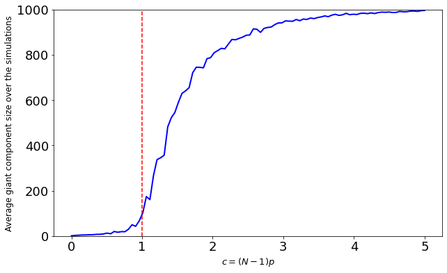

```python
plt.figure(figsize=(10,6))
plt.plot(c_list,np.mean(size_giant_component,axis=1),'b-',linewidth=2)
plt.plot([1,1],[0,N],'r--')
plt.ylim([0,N])
plt.ylabel('Average giant component size over the simulations',fontsize=12)
plt.xlabel(r'$c = (N-1)p$',fontsize=13)
plt.yticks(fontsize=18)
plt.xticks(fontsize=18);
```

# Configuration model

### 1. Get a degree sequence from Konect network which is *undirected*.

```python
# Read the file using bulit in python commmand and built directly from edge_list
fh = open("out.moreno_zebra_zebra", "rb")
# fh = open("out.opsahl-openflights", "rb")
G_zebra= nx.read_edgelist(fh, comments='%',create_using=nx.Graph())
fh.close()
```

### 2. Use the degree sequence and configuration model to generate network.

```python
degree_sequence= [d for u,d in G_zebra.degree()]
G_cm = nx.configuration_model(degree_sequence)
```

### 3. Visualize these two networks.

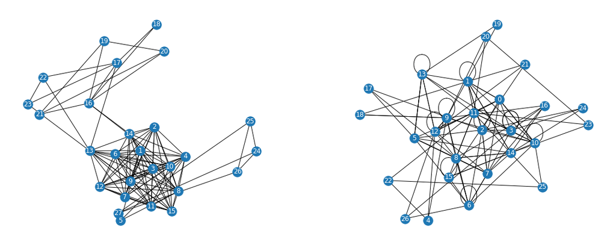

```python
plt.figure(figsize=(20,8))
plt.subplot(1,2,1)
nx.draw(G_zebra,with_labels=True,pos=nx.spring_layout(G_zebra,k=1.5,seed=5),font_color='w')
plt.subplot(1,2,2)
nx.draw(G_cm,with_labels=True,pos=nx.spring_layout(G_cm,k=1.5,seed=5),font_color='w')
```

### 4. Try it out yourself ! Compute the probability of having multiedges and selfloops in the generated graph.